# PracticalMachineLearningAssignment

HP

03/06/2020

**Introduction**

[output not shown]

**Data Source** The training data for this project are available here:

[https://d396qusza40orc.cloudfront.net/predmachlearn/pml-training.csv]

The test data are available here:

[https://d396qusza40orc.cloudfront.net/predmachlearn/pml-testing.csv]

The data for this project come from this source: [http://groupware.les.inf.puc-rio.br/har]. If you use the document you create for this class for any purpose please cite them as they have been very generous in allowing their data to be used for this kind of assignment.

**1. Loading the Dataset** The Dataset has been downloaded from the internet and has been loaded into two seperate dataframes, **“training__ and “testing”. The** “training__ data set has 19622 number of records and the **“testing** data set has 20 records. The number of variables is 160.

```r
library(caret)
```

```r
library(rpart.plot)
library(RColorBrewer)
library(RGtk2)
library(rattle)
library(randomForest)
library(gbm)
```

Here are the datasets, loaded directly from web and then downloaded.

```r
##train_url <- "http://d396qusza40orc.cloudfront.net/predmachlearn/pml-training.csv"
##test_url  <- "http://d396qusza40orc.cloudfront.net/predmachlearn/pml-testing.csv"

init_org_training_data <- read.csv("E:/2020/Coursera/Data Science JHU/Data Science Foundations using R Specialization/C9-PracticalMachineLearning/pml-training.csv")

init_org_testing_data <- read.csv("E:/2020/Coursera/Data Science JHU/Data Science Foundations using R Specialization/C9-PracticalMachineLearning/pml-testing.csv")

dim(init_org_training_data)
```

```
## [1] 19622   160
```

```r
dim(init_org_testing_data)
```

```
## [1]  20 160
```

**2. Data Cleansing** There are 3 parts in Data Cleansing.

A. Removing Variables which are having nearly zero variance.

```r
non_zero_var <- nearZeroVar(init_org_training_data)
org_training_data <- init_org_training_data[,-non_zero_var]
org_testing_data <- init_org_testing_data[,-non_zero_var]
dim(org_training_data)
```

```
## [1] 19622   100
```

```r
dim(org_testing_data)
```

```
## [1]  20 100
```

B. Removing Variables which are having NA values. Our threshhold is 95%.

```r
na_val_col <- sapply(org_training_data, function(x) mean(is.na(x))) > 0.95
org_training_data <- org_training_data[,na_val_col == FALSE]
org_testing_data <- org_testing_data[,na_val_col == FALSE]
dim(org_training_data)
```

```
## [1] 19622    59
```

```r
dim(org_testing_data)
```

```
## [1] 20 59
```

```r
org_training_data <- org_training_data[,8:59]
org_testing_data <- org_testing_data[,8:59]
dim(org_training_data)
```

```
## [1] 19622    52
```

```r
dim(org_testing_data)
```

```
## [1] 20 52
```

We can also check if the training data has the “classe” variable in it and the testing data has “problem_id” variable in it.

```r
##colnames_train <- names(org_training_data)
##org_training_data <- init_org_training_data[, c(colnames_train, "problem_id")]
colnames(org_training_data)
```

```
##  [1] "pitch_belt"           "yaw_belt"             "total_accel_belt"
##  [4] "gyros_belt_x"         "gyros_belt_y"         "gyros_belt_z"
##  [7] "accel_belt_x"         "accel_belt_y"         "accel_belt_z"
## [10] "magnet_belt_x"        "magnet_belt_y"        "magnet_belt_z"
## [13] "roll_arm"             "pitch_arm"            "yaw_arm"
## [16] "total_accel_arm"      "gyros_arm_x"          "gyros_arm_y"
## [19] "gyros_arm_z"          "accel_arm_x"          "accel_arm_y"
## [22] "accel_arm_z"          "magnet_arm_x"         "magnet_arm_y"
## [25] "magnet_arm_z"         "roll_dumbbell"        "pitch_dumbbell"
## [28] "yaw_dumbbell"         "total_accel_dumbbell" "gyros_dumbbell_x"
## [31] "gyros_dumbbell_y"     "gyros_dumbbell_z"     "accel_dumbbell_x"
## [34] "accel_dumbbell_y"     "accel_dumbbell_z"     "magnet_dumbbell_x"
## [37] "magnet_dumbbell_y"    "magnet_dumbbell_z"    "roll_forearm"
## [40] "pitch_forearm"        "yaw_forearm"          "total_accel_forearm"
## [43] "gyros_forearm_x"      "gyros_forearm_y"      "gyros_forearm_z"
## [46] "accel_forearm_x"      "accel_forearm_y"      "accel_forearm_z"
## [49] "magnet_forearm_x"     "magnet_forearm_y"     "magnet_forearm_z"
## [52] "classe"
```

```r
colnames(org_testing_data)
```

```
##  [1] "pitch_belt"           "yaw_belt"             "total_accel_belt"
##  [4] "gyros_belt_x"         "gyros_belt_y"         "gyros_belt_z"
##  [7] "accel_belt_x"         "accel_belt_y"         "accel_belt_z"
## [10] "magnet_belt_x"        "magnet_belt_y"        "magnet_belt_z"
## [13] "roll_arm"             "pitch_arm"            "yaw_arm"
## [16] "total_accel_arm"      "gyros_arm_x"          "gyros_arm_y"
## [19] "gyros_arm_z"          "accel_arm_x"          "accel_arm_y"
## [22] "accel_arm_z"          "magnet_arm_x"         "magnet_arm_y"
## [25] "magnet_arm_z"         "roll_dumbbell"        "pitch_dumbbell"
## [28] "yaw_dumbbell"         "total_accel_dumbbell" "gyros_dumbbell_x"
## [31] "gyros_dumbbell_y"     "gyros_dumbbell_z"     "accel_dumbbell_x"
## [34] "accel_dumbbell_y"     "accel_dumbbell_z"     "magnet_dumbbell_x"
## [37] "magnet_dumbbell_y"    "magnet_dumbbell_z"    "roll_forearm"
## [40] "pitch_forearm"        "yaw_forearm"          "total_accel_forearm"
## [43] "gyros_forearm_x"      "gyros_forearm_y"      "gyros_forearm_z"
## [46] "accel_forearm_x"      "accel_forearm_y"      "accel_forearm_z"
## [49] "magnet_forearm_x"     "magnet_forearm_y"     "magnet_forearm_z"
## [52] "problem_id"
```

**3. Data Partitioning** As per recommendation of the course __ Practical Machine Learning__ , we will be seggregating our org_training_data into 2 different parts, one is the training set (consisiting 60% of the total data) and test set (consisting 40% of the total data)

```r
inTrain <- createDataPartition(org_training_data$classe, p=0.6, list=FALSE)
training <- org_training_data[inTrain,]
testing <- org_training_data[-inTrain,]
dim(training)
```

```
## [1] 11776    52
```

```r
dim(testing)
```

```
## [1] 7846   52
```

**4.Decision Tree Model**

```r
DT_modfit <- train(classe ~ ., data = training, method="rpart")
```

Prediction in terms of Decision Tree Model

```r
DT_prediction <- predict(DT_modfit, testing)
confusionMatrix(DT_prediction,as.factor(testing$classe))
```

```
## Confusion Matrix and Statistics
##
##           Reference
## Prediction    A    B    C    D    E
##          A 1359  235   40   62   20
##          B  272  940  167  216  455
##          C  460  249 1129  399  410
##          D  138   94   32  609  156
##          E    3    0    0    0  401
##
## Overall Statistics
##
##                Accuracy : 0.5656
##                  95% CI : (0.5546, 0.5766)
##     No Information Rate : 0.2845
##     P-Value [Acc > NIR] : < 2.2e-16
##
##                   Kappa : 0.4553
##
##  Mcnemar's Test P-Value : < 2.2e-16
##
## Statistics by Class:
##
##                      Class: A Class: B Class: C Class: D Class: E
## Sensitivity            0.6089   0.6192   0.8253  0.47356  0.27809
## Specificity            0.9364   0.8246   0.7657  0.93598  0.99953
## Pos Pred Value         0.7920   0.4585   0.4265  0.59184  0.99257
## Neg Pred Value         0.8576   0.9003   0.9540  0.90069  0.86012
## Prevalence             0.2845   0.1935   0.1744  0.16391  0.18379
## Detection Rate         0.1732   0.1198   0.1439  0.07762  0.05111
## Detection Prevalence   0.2187   0.2613   0.3374  0.13115  0.05149
## Balanced Accuracy      0.7726   0.7219   0.7955  0.70477  0.63881
```

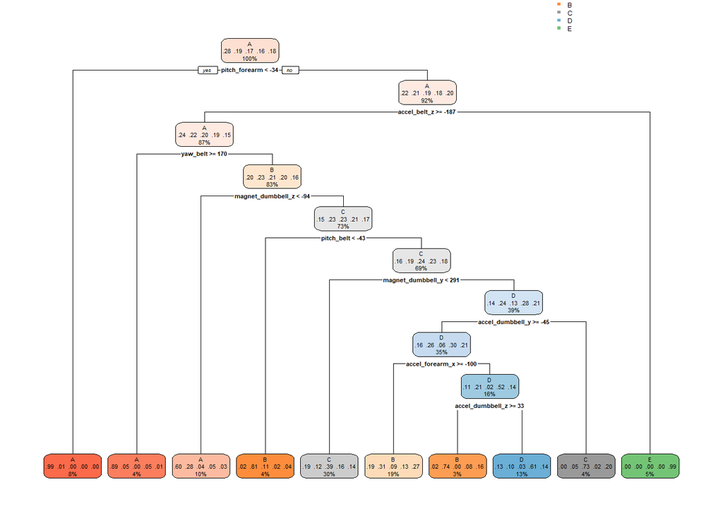

```r
rpart.plot(DT_modfit$finalModel, roundint=FALSE)
```

**5. Random Forest Model**

```r
RF_modfit <- train(classe ~ ., data = training, method = "rf", ntree = 100)
```

Prediction in terms of Random Forest Model

```r
RF_prediction <- predict(RF_modfit, testing)
RF_pred_conf <- confusionMatrix(RF_prediction,as.factor(testing$classe))
RF_pred_conf
```

```
## Confusion Matrix and Statistics
##
##           Reference
## Prediction    A    B    C    D    E
##          A 2231   16    0    0    0
##          B    0 1495   11    0    0
##          C    0    6 1350   29    2
##          D    0    0    7 1255    6
##          E    1    1    0    2 1434
##
## Overall Statistics
##
##                Accuracy : 0.9897
##                  95% CI : (0.9872, 0.9918)
##     No Information Rate : 0.2845
##     P-Value [Acc > NIR] : < 2.2e-16
##
##                   Kappa : 0.9869
##
##  Mcnemar's Test P-Value : NA
##
## Statistics by Class:
##
##                      Class: A Class: B Class: C Class: D Class: E
## Sensitivity            0.9996   0.9848   0.9868   0.9759   0.9945
## Specificity            0.9971   0.9983   0.9943   0.9980   0.9994
## Pos Pred Value         0.9929   0.9927   0.9733   0.9897   0.9972
## Neg Pred Value         0.9998   0.9964   0.9972   0.9953   0.9988
## Prevalence             0.2845   0.1935   0.1744   0.1639   0.1838
## Detection Rate         0.2843   0.1905   0.1721   0.1600   0.1828
## Detection Prevalence   0.2864   0.1919   0.1768   0.1616   0.1833
## Balanced Accuracy      0.9984   0.9916   0.9906   0.9870   0.9969
```

Here is the plot

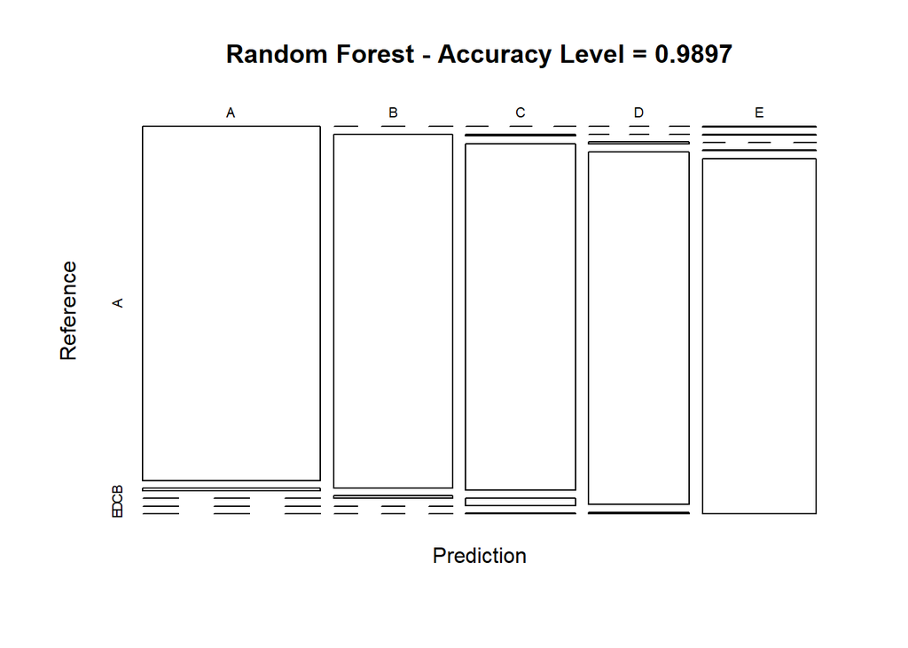

```r
plot(RF_pred_conf$table, col = RF_pred_conf$byClass,
     main = paste("Random Forest - Accuracy Level =",
                  round(RF_pred_conf$overall['Accuracy'], 4)))
```

From the Confusion Matrix, we can clearly notice that the prediction accuracy of Random Forest model is 99% which is satisfactory.

**6.Gradient Boosting Model**

```r
GBM_modfit <- train(classe ~ ., data = training, method = "gbm", verbose = FALSE)
GBM_modfit$finalModel
```

```
## A gradient boosted model with multinomial loss function.
## 150 iterations were performed.
## There were 51 predictors of which 51 had non-zero influence.
```

Prediction in terms of GBM Model

```r
#GBM_prediction <- predict(GBM_modfit, testing, type = "class", n.trees = 5, type = link)
GBM_prediction <- predict(GBM_modfit, testing)
GBM_pred_conf <- confusionMatrix(GBM_prediction,as.factor(testing$classe))
GBM_pred_conf
```

```
## Confusion Matrix and Statistics
##
##           Reference
## Prediction    A    B    C    D    E
##          A 2188   56    1    2    2
##          B   18 1416   32    3   25
##          C   11   37 1317   59   11
##          D   11    0   16 1214   25
##          E    4    9    2    8 1379
##
## Overall Statistics
##
##                Accuracy : 0.9577
##                  95% CI : (0.953, 0.962)
##     No Information Rate : 0.2845
##     P-Value [Acc > NIR] : < 2.2e-16
##
##                   Kappa : 0.9465
##
##  Mcnemar's Test P-Value : 4.601e-14
##
## Statistics by Class:
##
##                      Class: A Class: B Class: C Class: D Class: E
## Sensitivity            0.9803   0.9328   0.9627   0.9440   0.9563
## Specificity            0.9891   0.9877   0.9818   0.9921   0.9964
## Pos Pred Value         0.9729   0.9478   0.9178   0.9589   0.9836
## Neg Pred Value         0.9921   0.9839   0.9920   0.9891   0.9902
## Prevalence             0.2845   0.1935   0.1744   0.1639   0.1838
## Detection Rate         0.2789   0.1805   0.1679   0.1547   0.1758
## Detection Prevalence   0.2866   0.1904   0.1829   0.1614   0.1787
## Balanced Accuracy      0.9847   0.9602   0.9723   0.9680   0.9764
```

Here is the plot

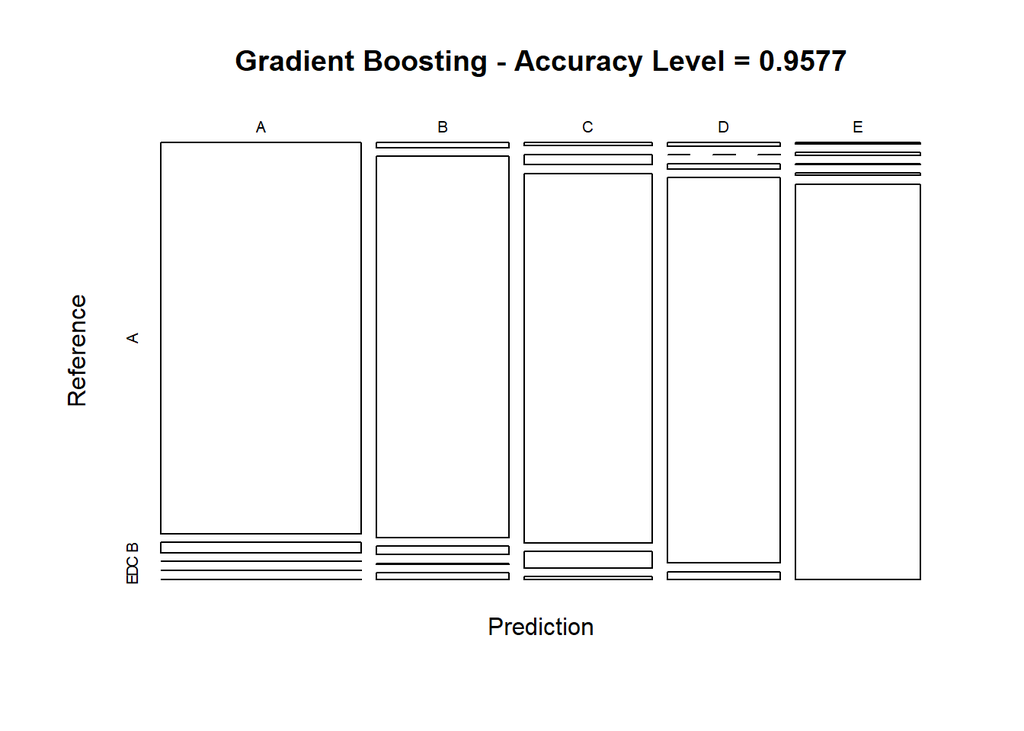

```r
plot(GBM_pred_conf$table, col = GBM_pred_conf$byClass,
     main = paste("Gradient Boosting - Accuracy Level =",
                  round(GBM_pred_conf$overall['Accuracy'], 4)))
```

From Gradient Boost Model, the prediction accuracy is 95% which is satisfactory.

**Now we need to see how each model has predicted the validation dataset across the classifications.** We are not considering Decision Tree model as it didn’t reach the satisfactory prediction accuracy level. SO only Random Forest and Gradient Boosting methods are being compared.

```r
RF_pred_conf$overall
```

```
##       Accuracy          Kappa  AccuracyLower  AccuracyUpper   AccuracyNull
##      0.9896763      0.9869386      0.9871847      0.9917933      0.2844762
## AccuracyPValue  McnemarPValue
##      0.0000000            NaN
```

```r
GBM_pred_conf$overall
```

```
##       Accuracy          Kappa  AccuracyLower  AccuracyUpper   AccuracyNull
##   9.576854e-01   9.464670e-01   9.529942e-01   9.620327e-01   2.844762e-01
## AccuracyPValue  McnemarPValue
##   0.000000e+00   4.601244e-14
```

**Conclusion** After checking the Overall Statistics data, the Random Forest model has definitely more accuracy than GBM. Hence we will be selecting Random Forest model for final prediction from org_testing_data .

**Final Prediction- Applying selected model on the Test Data**

```r
Final_RF_prediction <- predict(RF_modfit, org_testing_data )
Final_RF_prediction
```

```
##  [1] B A B A A E D B A A B C B A E E A B B B
## Levels: A B C D E
```